# U2L4 - Linear Regression

September 11, 2023

## Front Matter

```r
#Delete all objects from Environment - Use with caution
remove(list = ls())

#Load Libraries
library(tidyverse)
#Load Datasets
Vehicles <- read.csv("../sample_data/L04_Vehicles_m.csv")
Ins <- read.csv("../sample_data/L01_Insurance_m.csv")
```

## Example - Basics of MLR

#### Part a - Renaming variables and handling missingness

```r
#Create Descriptive Variable Names
Vehicles <- Vehicles %>%
  rename(Price = V1,
         Miles = V2,
         Manufacturer = V3,
         Model = V4)
#Caution: If you run this chunk more than once, you will get an error message because V1, V2, V3, V4 no longer exist
```

```r
#Check for missingness
apply(X = Vehicles, MARGIN = 2, FUN = function(x) sum(is.na(x)))

#Remove observations with missing values
Vehicles <- na.omit(Vehicles)
```

#### Part b - Is there a linear association between price and miles?

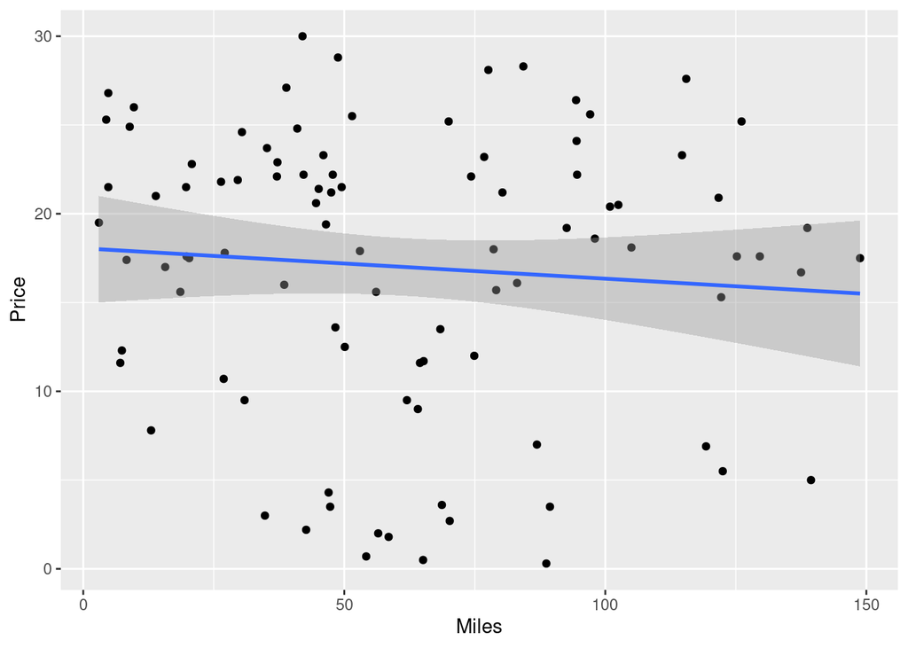

```r
#Create a visualization
ggplot(data = Vehicles, mapping = aes(x = Miles, y = Price)) +
  geom_point() +
  geom_smooth(method = lm)
```

```r
#Provide summary statistics
cor(x = Vehicles$Miles, y = Vehicles$Price)
```

```
## [1] NA
```

#### Part c - What other variables could explain price?

- Condition of the car (scratches, dents, rust, etc.)
- Whether the vehicle has been involved in an accident
- Features of the vehicle (AC, sun roof, 2 or 4 doors)
- Model of the car and/or the manufacturer of the car

#### Part d - Is there an association between prices, miles, and model?

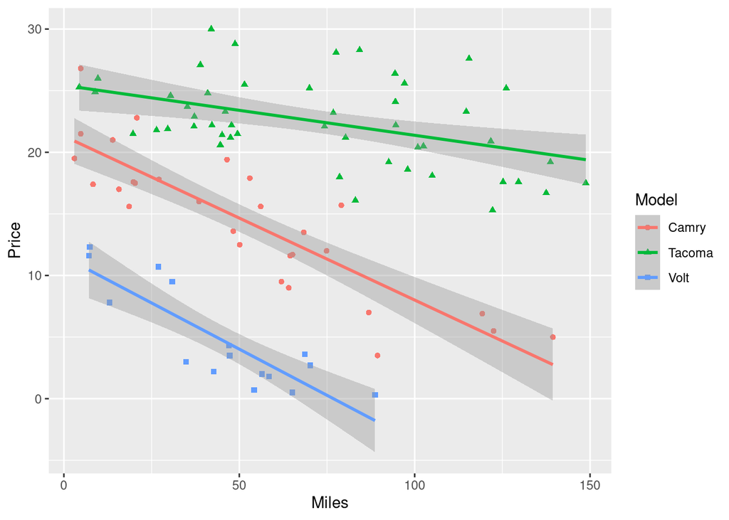

```r
#Create a visualization
ggplot(data = Vehicles, mapping = aes(x = Miles, y = Price, color = Model, shape = Model)) +
  geom_point() +
  geom_smooth(method = lm)
```

Some observations:

- Within each model, there is a negative linear association. As miles increases, price decreases.
- The rate of change in price with respect to miles (i.e., the slopes) may be different for the different models. It looks like Camry’s and Volt’s have similar slopes, but the slope for Tacoma’s may not be as steep.
- For a given number of miles, Tacoma’s are more expensive than Camry’s and Camry’s are more expensive than Volt’s.

#### Part e - Defining Indicator Variables

The indicator for Camry is given by:

$$x_{i,Camry} =
\begin{cases}
1 & \text{Model = Camry} \\
0 & \text{Model }\ne \text{Camry}
\end{cases}$$

The indicator for Tacoma is given by:

$$x_{i,Tacoma} =
\begin{cases}
1 & \text{Model = Tacoma} \\
0 & \text{Model }\ne \text{Tacoma}
\end{cases}$$

#### Part f - Understanding Indicators

| Camry $(x_{i,2})$ | Tacoma $(x_{i,3})$ | Implied Model of Car |
| --- | --- | --- |
| 1 | 0 | Camry |
| 0 | 1 | Tacoma |
| 0 | 0 | Volt |

NOTE: The value implied when all indicators are 0 is often called the “baseline”. In this case, the Volt is the baseline.

#### Part g - Build Regression Model for Price

```r
#Create Indicators for Camry and Tacoma
Vehicles <- Vehicles %>%
  mutate(Camry = ifelse(Model == "Camry", 1,0)) %>%
  mutate(Tacoma = ifelse(Model == "Tacoma", 1,0))


#Build the model and present a summary
model1 <- lm(Price ~ Miles + Camry + Tacoma, data = Vehicles)
summary(model1)
```

```
##
## Call:
## lm(formula = Price ~ Miles + Camry + Tacoma, data = Vehicles)
##
## Residuals:
##    Min     1Q Median     3Q    Max
## -8.013 -2.485 -0.548  1.945  8.677
##
## Coefficients:
##              Estimate Std. Error t value Pr(>|t|)
## (Intercept)  8.292355   0.958856   8.648 1.86e-13 ***
## Miles       -0.078133   0.009862  -7.923 5.88e-12 ***
## Camry       10.205957   1.061015   9.619 1.77e-15 ***
## Tacoma      19.876760   1.017201  19.541  < 2e-16 ***
## ---
## Signif. codes:  0 '***' 0.001 '**' 0.01 '*' 0.05 '.' 0.1 ' ' 1
##
## Residual standard error: 3.401 on 90 degrees of freedom
##   (2 observations deleted due to missingness)
## Multiple R-squared:  0.8208, Adjusted R-squared:  0.8148
## F-statistic: 137.4 on 3 and 90 DF,  p-value: < 2.2e-16
```

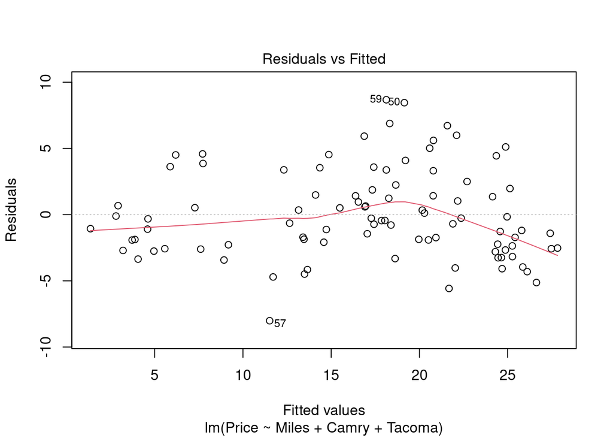

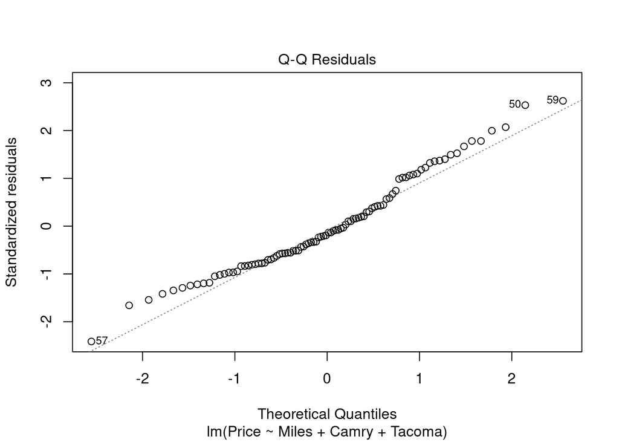

```r
#Generate Plots for Checking Assumptions (Not covered in notes)
#plot(model1, which = c(1,2))
plot(model1, which = c(1,2))
```

The estimated regression coefficients are found in the Estimate column of the Coefficients table in the R output. The estimated regression equation is given by:

$$\hat{y}_{i} = 8.29 - 0.08 x_{i,miles} +
10.21 x_{i,Camry} + 19.88 x_{i, Tacoma}$$

#### Part h - Predict the price for a Tacoma with 105.0 thousands of miles.

```r
#Prediction using predict() function
predict(model1, newdata = data.frame(Miles = 105, Tacoma = 1, Camry = 0))
```

```
##        1
## 19.96514
```

#### Part j - Interpret the coefficients

#### Part k - Find confidence Intervals for the regression coefficients

```r
confint(model1, level = 0.95)
```

[output not shown]

## Example - R Generated Indicator Variables

#### Part a - Let R create the indicator variables

```r
model1b <- lm(Price ~ Miles + Model, data = Vehicles)
summary(model1b)
```

[output not shown]

#### Part b - Use 3 indicator variables

```r
Vehicles <-
  Vehicles %>%
  mutate(Volt = ifelse(Model == "Volt", 1,0))

model1c <- lm(Price ~ Miles + Camry + Tacoma + Volt, data = Vehicles)
summary(model1c)
```

[output not shown]

## Example - Random Number Generation in R

#### Part a - “Randomly” generating numbers in R

```r
#Randomly generate 9 numbers from 1 to 20 with replacement
sample(x = 1:20, size = 9, replace = TRUE)
```

```
## [1]  7 16  6  8 16 17  7  1 10
```

#### Part b - “Randomly” generating numbers in R with a seed

```r
#Randomly generate 9 numbers from 1 to 20 using a seed of 1234
set.seed(1234)
sample(x = 1:20, size = 9, replace = TRUE) #16  5 12 15  9  5  6 16  4
```

```
## [1] 16  5 12 15  9  5  6 16  4
```

```r
set.seed(NULL)
```

#### Part c - What purpose does set.seed(NULL) serve?

```r
#Randomly generate 3 numbers from 1 to 20 3 times using a seed of 1234
set.seed(1234)
sample(x = 1:20, size = 3, replace = TRUE) #16  5 12
```

```
## [1] 16  5 12
```

```r
sample(x = 1:20, size = 3, replace = TRUE) #15  9  5
```

```
## [1] 15  9  5
```

```r
sample(x = 1:20, size = 3, replace = TRUE) #6 16  4
```

```
## [1]  6 16  4
```

```r
set.seed(NULL)

#What does set.seed(NULL) do?
set.seed(1234)
sample(x = 1:20, size = 3, replace = TRUE) #16  5 12
```

```
## [1] 16  5 12
```

```r
sample(x = 1:20, size = 3, replace = TRUE) #15  9  5
```

```
## [1] 15  9  5
```

```r
set.seed(NULL)
sample(x = 1:20, size = 3, replace = TRUE) #Not using a seed (results will be random)
```

```
## [1] 14  2 15
```

## Example - Comparing Models Using Validation Set Approach

#### Part a - Remove Missing Values and split into training and validation sets

```r
#Remove any observations with missing data
Ins <-na.omit(Ins)
```

```r
#Perform training/validation split
set.seed(42)
train_ind <- sample(x = 1:nrow(Ins), size = floor(0.8*nrow(Ins)), replace = FALSE)
set.seed(NULL)

train <- Ins[train_ind,]
validation <- Ins[-train_ind,]
```

#### Part b - EDA plot using the training data

```r
ggplot(data = train, mapping = aes(x = bmi, y = charges,
                                   color = smoker, shape = smoker)) +
  geom_point() +
  geom_smooth(method = "lm", se = FALSE) +
  labs(x = "Body Mass Index",
       y = "Charges",
       color = "Smoking Status",
       shape = "Smoking Status")
```

[output not shown]

Observations:

#### Part c - Build model for predicting charges using bmi and smoking status

```r
model1 <- lm(charges ~ bmi + smoker, data = train)
summary(model1)
```

```
##
## Call:
## lm(formula = charges ~ bmi + smoker, data = train)
##
## Residuals:
##      Min       1Q   Median       3Q      Max
## -15790.5  -4714.4   -878.2   3718.1  30828.5
##
## Coefficients:
##             Estimate Std. Error t value Pr(>|t|)
## (Intercept) -3056.11    1136.55  -2.689  0.00728 **
## bmi           376.62      35.97  10.470  < 2e-16 ***
## smokeryes   23386.14     537.49  43.510  < 2e-16 ***
## ---
## Signif. codes:  0 '***' 0.001 '**' 0.01 '*' 0.05 '.' 0.1 ' ' 1
##
## Residual standard error: 7233 on 1066 degrees of freedom
## Multiple R-squared:  0.6521, Adjusted R-squared:  0.6515
## F-statistic: 999.1 on 2 and 1066 DF,  p-value: < 2.2e-16
```

#### Part d - Describe the order of operations fo calculating MSE

The MSE is given by:

$$MSE = \frac{1}{n}\sum_{i=1}^n (y_{i} -
\hat{y}_{i})^2$$

Steps:

1. Calculate the predicted responses (yhat)
2. Calculate the residuals (y - yhat)
3. Square the residuals
4. Find the mean of the squared residuals
   - Sum the residuals
   - Multiply by (1/n) or divide by n

#### Part e - Calculate MSE and RMSE for training data

```r
#MSE Train - Use the residuals stored from the estimating the model using train
MSEtrain1 <- mean(model1$residuals^2)
RMSEtrain1 <- sqrt(MSEtrain1)

MSEtrain1
```

```
## [1] 52166959
```

```r
RMSEtrain1
```

```
## [1] 7222.67
```

#### Part f - Calculate the MSE and RMSE for the valdiation data

```r
#MSE Validation
#First find predictions on validation
yhatVal1 <- predict(model1, newdata = validation)
#Using predictions from validation, calculate squared residuals and find the mean
MSEval1 <- mean((validation$charges - yhatVal1)^2)
RMSEval1 <- sqrt(MSEval1)

MSEval1
```

```
## [1] 42193570
```

```r
RMSEval1
```

```
## [1] 6495.658
```

```r
#Build the model
model2 <- lm(charges ~ bmi + smoker + region, data = train)
model2 <- lm(bmi ~ age + sex + smoker + region, data = train)
#MSE and RMSE of Train
MSEtrain2 <- mean((model2$residuals)^2)
RMSEtrain2 <- sqrt(MSEtrain2)

#MSE and RMSE of Validation
yhatVal2 <- predict(model2, newdata = validation)
MSEval2 <- mean((validation$charges - yhatVal2)^2)
RMSEval2 <- sqrt(MSEval2)

MSEtrain2
RMSEtrain2
MSEval2
RMSEval2
```

[output not shown]

#### Part h - Comparing Models

```r
#Since I want to create new variables, I either a) have to create the variables in the original dataset and repeat the split into training and validation sets OR b) create the variables within both the training and validation sets as shown below

#Create new variables in train
train <-
  train %>%
  mutate(smokes = ifelse(smoker == "yes", 1, 0),
         bmismokes = bmi*smokes)

#Create new variables in validation
validation <-
  validation %>%
  mutate(smokes = ifelse(smoker == "yes", 1, 0),
         bmismokes = bmi*smokes)

#Build model with interaction term
model3 <- lm(charges ~ bmi + smoker + bmismokes, data = train)
summary(model3)

#MSE Train
MSEtrain3 <- mean((model3$residuals)^2)
RMSEtrain3 <- sqrt(MSEtrain3)

#MSE Validation
yhatVal3 <- predict(model3, newdata = validation)
MSEval3 <- mean((validation$charges - yhatVal3)^2)
RMSEval3 <- sqrt(MSEval3)

MSEtrain3
RMSEtrain3
MSEval3
RMSEval3
```

[output not shown]

## k-Fold CV Code (Not discussed in notes)

```r
#Create a vector with the fold values
#Each observation will be assigned a value from 1 to k where k is the number of folds
num_folds <- 5 #this is the k in k-fold; here we are doing 5-fold cross validation
folds <- cut(x = 1:nrow(Ins), breaks = num_folds, labels = FALSE)

#Randomly permute/mix up the values so that the values in folds are not in order
#This is equivalent to mixing up the row numbers in Figure 5.5
set.seed(123)
folds <- sample(folds)
set.seed(NULL)

#Set up Loop storage
MSE_vec <- rep(NA, num_folds) #Creates a vector where NA is repeated num_folds times
                              #This is for storing the MSE of each fold

#Loop through the folds - each time remove one fold to use as validation set; rest is train
for(i in 1:num_folds){
  #Training/Valiation Split - different than before
  validation_ind <- which(folds == i)
  validation <- Ins[validation_ind, ]
  train <- Ins[-validation_ind, ]

  #Build model
  temp_reg <- lm(charges ~ bmi + smoker, data = train)

  #Find MSE
  yhat <- predict(temp_reg, newdata = validation)
  mse <- mean((validation$charges - yhat)^2)
  MSE_vec[i] <- mse
}

#Display MSE values (there should be one for each fold)
MSE_vec

#Find the mean of the MSE values (book calls this CV_(k))
mean(MSE_vec)

#For a more interpretation answer, report the square root of the mean MSE
sqrt(mean(MSE_vec))
```

[output not shown]